# Contaminación atmosférica y ómica cerebral de ratón

Metodología detallada, reproducción de estudios y análisis del proyecto

29 octubre 2026

## Alcance científico y niveles de evidencia

01 / Contexto

04

estudios de exposición independientes

- **Pregunta:** ¿qué patrones regionales de expresión acompañan los experimentos originales de exposición en ratón?
- **Reproducción:** recuperar resultados de los autores usando los mismos animales fuente.
- **Extensiones del proyecto:** contrastes principales nuevos, enriquecimiento, interacciones y modelos de referencia espacial.
- **Interpretación espacial:** se distinguen células medidas sin exposición, estimaciones ajustadas y un escenario ilustrativo con PM₂.₅.

Referencias científicas[Rajagopalan et al., JCI 2020](https://doi.org/10.1172/JCI137315) · [Zhang et al., Science 2025](https://doi.org/10.1126/science.adu4132) · [Nakamya et al., IJMS 2025](https://doi.org/10.3390/ijms26062407)

## La región cerebral y el diseño de exposición definen la pregunta

01 / Contexto

Las mediciones regionales de ARN permiten estudiar asociaciones de expresión bajo una ruta, dosis, genotipo y edad concretos.

El proyecto aborda tres preguntas relacionadas:

1. ¿Se pueden reconstruir los análisis depositados por los autores?
2. ¿Qué muestran los reanálisis explícitos y las pruebas de interacción de respuesta?
3. ¿Dónde se detectan los transcritos priorizados en una referencia cerebral medida e independiente?

Referencias científicas[Rajagopalan et al., JCI 2020](https://doi.org/10.1172/JCI137315) · [Zhang et al., Science 2025](https://doi.org/10.1126/science.adu4132) · [Nakamya et al., IJMS 2025](https://doi.org/10.3390/ijms26062407)

## Dos estudios RNA-seq de PM₂.₅

01 / Contexto

| Característica | Hipotálamo | Corteza cingulada anterior |
| --- | --- | --- |
| Depósito | GSE145840 | GSE297423 |
| Animales principales | 4 FA + 3 PM | 4 PBS + 4 PM |
| Modelo / contexto | C57BL/6J macho, dieta estándar | α-sinucleína hWT humanizada, sexo no informado |
| Ruta de exposición | Inhalación de aerosol ambiental concentrado | Suspensión de PM intranasal repetida |
| Material de partida | Siete archivos de conteos génicos | Ocho bibliotecas de una matriz de 20 |
| Inferencia principal | PyDESeq2, PM frente a FA | PyDESeq2, PM frente a PBS |

Referencias científicas[Rajagopalan et al., JCI 2020](https://doi.org/10.1172/JCI137315) · [Zhang et al., Science 2025](https://doi.org/10.1126/science.adu4132)

## Estudios hipocampales de miRNA y ozono

01 / Contexto

| Característica | miRNA con PM₂.₅ | RNA-seq de ozono |
| --- | --- | --- |
| Depósito | GSE93967 | E-MTAB-14917 |
| Animales medidos | 9 arrays, 3 por grupo | 24 animales, 3 en cada uno de 8 estratos |
| Diseño | Salina, PM de 1 o 5 mg/kg | 2 edades × 2 genotipos APOE × 2 exposiciones |
| Ensayo | Microarray Agilent miRNA V19 | RNA-seq paired-end de hipocampo izquierdo |
| Entrada | Señal con normalización cuantílica depositada | Pares FASTQ originales |
| Escala | Unidades originales de señal | Fragmentos génicos estimados + offsets de longitud |

Referencias científicas[Ku et al., Part. Fibre Toxicol. 2017](https://doi.org/10.1186/s12989-017-0215-3) · [Nakamya et al., IJMS 2025](https://doi.org/10.3390/ijms26062407)

## Unidades experimentales y poblaciones analíticas

01 / Contexto

01

donante espacial sin exposición

- **Bulk y arrays:** el animal secuenciado o medido es la réplica biológica.
- **Reproducción de autores:** los mismos animales depositados permiten evaluar concordancia computacional.
- **Referencia espacial:** 52,393 células ACA/HY proceden de un donante sin exposición.
- **Validación espacial:** reservar cortes evalúa predicción dentro del donante.

No se estima una dosis conjunta de contaminantes, un efecto combinado entre estudios ni una prueba de exposición con células independientes.

Referencias científicas[Rajagopalan et al., JCI 2020](https://doi.org/10.1172/JCI137315) · [Zhang et al., Science 2025](https://doi.org/10.1126/science.adu4132) · [Nakamya et al., IJMS 2025](https://doi.org/10.3390/ijms26062407)

## El contraste bulk y las células espaciales responden preguntas distintas

01 / Contexto

**Comparación de exposición.** RNA-seq bulk reúne ARN de muchas células de cada región. El animal aporta la réplica independiente. Una diferencia regional puede reflejar expresión dentro de células, cambios de composición o ambos.

**Referencia espacial.** MERFISH cuenta un panel dirigido en posiciones celulares medidas de un donante sin exposición. Muestra dónde se detecta un transcrito en esa referencia.

**Conexión.** Vinculamos los candidatos regionales con el panel medido. El atlas aporta contexto anatómico y el experimento de exposición independiente aporta el contraste regional.

Referencias científicas[Rajagopalan et al., JCI 2020](https://doi.org/10.1172/JCI137315) · [Zhang et al., Science 2025](https://doi.org/10.1126/science.adu4132) · [Zhang et al., Nature 2023](https://doi.org/10.1038/s41586-023-06808-9)

## Flujo del proyecto y procedencia

01 / Contexto

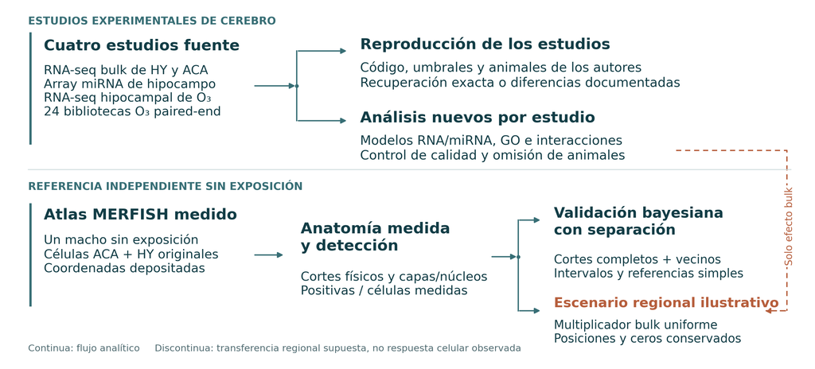

La rama superior sigue los datos de exposición hasta la reproducción y los análisis nuevos por estudio. La inferior parte de un donante MERFISH independiente sin exposición. Su anatomía medida sustenta modelos de referencia. La transferencia bulk discontinua entra solo al escenario ilustrativo, sin implicar respuestas celulares medidas a la exposición.

Diapositiva interactiva de hipotálamo · Diapositiva interactiva de corteza

Análisis: este proyecto[Rajagopalan et al., JCI 2020](https://doi.org/10.1172/JCI137315) · [Zhang et al., Science 2025](https://doi.org/10.1126/science.adu4132) · [Nakamya et al., IJMS 2025](https://doi.org/10.3390/ijms26062407)

## Fosb a través de los análisis experimental y espacial

01 / Contexto

**Evidencia regional.** El contraste ACA de ocho animales estima mayor ARN Fosb con PM. Su log₂ fold change regularizado es +0.99711, equivalente a un multiplicador de 1.996.

**Referencia medida.** El atlas independiente detecta Fosb en 1,418 de 14,582 células ACA. Las coordenadas originales ubican las detecciones en la anatomía registrada.

**Visualización ilustrativa.** Multiplicar cada valor de referencia por 1.996 cambia color y magnitud, conservando posiciones y ceros medidos. Este supuesto ilustra la estimación regional sin identificar qué células responden realmente a PM.

Referencias científicas[Zhang et al., Science 2025](https://doi.org/10.1126/science.adu4132) · [Zhang et al., Nature 2023](https://doi.org/10.1038/s41586-023-06808-9) · [Love et al., Genome Biol. 2014](https://doi.org/10.1186/s13059-014-0550-8)

## Metodología

02 / Metodología

Reconstrucción de los estudios originales, análisis estadísticos nuevos y referencia espacial medida

## Criterios de reproducción computacional

02 / Metodología

| Nivel | Comparación | Interpretación |
| --- | --- | --- |
| Entradas | Identificadores, conteos, muestras y hashes | Verificar el mismo punto de partida |
| Modelo | Diseño, normalización, filtro y familia de multiplicidad | Reconstruir el procedimiento declarado |
| Salidas | Identidades, efectos, valores p y conjuntos seleccionados | El número de genes por sí solo es insuficiente |
| Especificación faltante | Parámetros no recuperados o cuantificación distinta | Declarar sensibilidad o concordancia |

Referencias científicas[Rajagopalan et al., JCI 2020](https://doi.org/10.1172/JCI137315) · [Zhang et al., Science 2025](https://doi.org/10.1126/science.adu4132) · [Nakamya et al., IJMS 2025](https://doi.org/10.3390/ijms26062407)

## Recuperación numérica y validación biológica independiente

02 / Metodología

**Recuperación numérica** pregunta si las mismas entradas y reglas recuperan efectos, probabilidades y genes seleccionados por los autores. Corteza recupera exactamente los cuatro conjuntos significativos cotejados.

**Sensibilidad metodológica** pregunta qué cambia al modificar modelo, filtro o población analítica. La reconstrucción hipotalámica queda incompleta porque faltan especificaciones RUVg.

**Validación biológica independiente** exigiría animales o experimentos adicionales. Reanalizar los animales fuente, incluso con otro software, comprueba cálculos y supuestos sin modificar el tamaño muestral biológico.

Referencias científicas[Zhang et al., Science 2025](https://doi.org/10.1126/science.adu4132) · [Rajagopalan et al., JCI 2020](https://doi.org/10.1172/JCI137315)

## Análisis cortical de conteos alineado con los autores

02 / Metodología

1. Cotejar la matriz original de Zenodo con el depósito GEO.
2. Conservar las **20 bibliotecas de cinco grupos de tratamiento**.
3. Retener genes con ≥10 conteos en ≥4 bibliotecas: **21,388 genes**.
4. Reconstruir R DESeq2 con diseño `~group`.
5. Conservar α = 0.1 del filtrado independiente por defecto y seleccionar **BH q < 0.05**.
6. Reconstruir el PCA definido por código: TMM log₂CPM, 500 genes más variables y escalamiento por varianza.

Referencias científicas[Zhang et al., Science 2025](https://doi.org/10.1126/science.adu4132)

## La especificación RUVg hipotalámica sigue incompleta

02 / Metodología

El artículo describe normalización por carril, controles empíricos y RUVg antes de las pruebas.

- No están disponibles los **5,000 genes de control negativo** exactos ni el número **k** de factores.
- Una sensibilidad declarada utiliza las 11 bibliotecas FA/PM/HFD con TMM/voom y limma, **sin inventar factores RUVg**.
- Universo común: 50,417 características. Se excluyen 91 filas exclusivas HFD sin inventar ceros.
- El filtro codificante GENCODE M13 y el filtro CPM dejan 13,398 genes evaluados.

Referencias científicas[Rajagopalan et al., JCI 2020](https://doi.org/10.1172/JCI137315)

## Reconstrucción del objetivo miRNA y criterios de prueba

02 / Metodología

- Recuperar el objetivo preespecificado de la Figura 6: **mmu-miR-574-5p**.
- Conservar los nueve arrays y su señal normalizada original.
- Reconstruir ANOVA y comparaciones LSD con MSE agrupado.
- Distinguir la **prueba pareada no protegida** del **LSD protegido que exige significación ómnibus**.
- Comparar el objetivo con el análisis limma moderado nuevo y su familia BH de todo el array.

Referencias científicas[Ku et al., Part. Fibre Toxicol. 2017](https://doi.org/10.1186/s12989-017-0215-3) · [Ritchie et al., NAR 2015](https://doi.org/10.1093/nar/gkv007)

## Reconstrucción de tablas de ozono y comparación entre flujos

02 / Metodología

**Reconstrucción exacta de selección**

La tabla depositada E4/E3 contiene efectos de genotipo. Aplicar su regla de p nominal < 0.05 y |log₂FC| > 0.3.

**Concordancia condicional de efectos**

Comparar efectos finitos con símbolo exacto obtenidos de los conteos Salmon/tximport nuevos con resultados publicados. Reestimar dispersiones en los modelos candidatos declarados.

No se reconstruyen íntegramente HISAT2/featureCounts, la anotación histórica ni toda la especificación de pruebas.

Referencias científicas[Nakamya et al., IJMS 2025](https://doi.org/10.3390/ijms26062407)

## Modelo binomial negativo para conteos de ARN

02 / Metodología

$$K_{gi}\sim\mathrm{NB}(\mu_{gi},\alpha_g),\qquad
\operatorname{Var}(K_{gi})=\mu_{gi}+\alpha_g\mu_{gi}^{2}$$

$$\log\mu_{gi}=\log o_{gi}+\mathbf x_i^\top\boldsymbol\beta_g$$

- $K_{gi}$: conteos asignados o fragmentos estimados redondeados.
- $\alpha_g$: dispersión por gen, estimada con regularización.
- $o_{gi}$: factor de normalización. En ozono incorpora información de longitud efectiva.
- La matriz de diseño define la comparación antes de la prueba.

Referencias científicas[Love et al., Genome Biol. 2014](https://doi.org/10.1186/s13059-014-0550-8) · [Muzellec et al. 2023](https://doi.org/10.1093/bioinformatics/btad547)

## Normalización y dispersión en el modelo de conteos

02 / Metodología

**Normalización** ajusta diferencias técnicas en la cantidad de ARN secuenciado. Sin ella, una biblioteca profunda podría parecer mayor en muchos genes sin cambio biológico. Ozono incorpora además longitudes efectivas de la cuantificación transcriptómica.

**Dispersión** describe variación entre animales adicional al ruido ordinario de conteo. Un gen variable necesita una diferencia grupal mayor y más consistente para aportar evidencia fuerte.

**El coeficiente** estima el contraste regional elegido tras esos ajustes. Normalizar y estimar dispersión no crea réplicas biológicas ni elimina una fuente de confusión no medida.

Referencias científicas[Love et al., Genome Biol. 2014](https://doi.org/10.1186/s13059-014-0550-8) · [Muzellec et al. 2023](https://doi.org/10.1093/bioinformatics/btad547) · [Soneson et al. 2015](https://doi.org/10.12688/f1000research.7563.2)

## Filtrado de conteos y poblaciones de normalización

02 / Metodología

| Análisis | Filtro de conteos | Genes retenidos | Muestras ajustadas |
| --- | --- | --- | --- |
| HY principal | ≥10 en ≥3 | 19,611 | 7 |
| ACA principal | ≥10 en ≥4 | 19,235 | 8 |
| ACA reconstrucción autores | ≥10 en ≥4 | 21,388 | 20 |
| O₃ principal | ≥10 en ≥3 | 18,537 | 24 |

Los análisis PM principales usan factores por mediana de cocientes. Cambiar las muestras ajustadas modifica el filtro y las dispersiones.

Referencias científicas[Rajagopalan et al., JCI 2020](https://doi.org/10.1172/JCI137315) · [Zhang et al., Science 2025](https://doi.org/10.1126/science.adu4132) · [Nakamya et al., IJMS 2025](https://doi.org/10.3390/ijms26062407)

## Evidencia Wald, regularización y pruebas múltiples

02 / Metodología

$$z_g=\frac{\widehat\beta_g}{\operatorname{SE}(\widehat\beta_g)},
\qquad \mathrm{IC}_{95\%}=\widehat\beta_g\pm1.959964\,\operatorname{SE}(\widehat\beta_g)$$

$$q_{(i)}=\min\!\left(1,\min_{j\ge i}\frac{m\,p_{(j)}}{j}\right)$$

- MLE, SE y valores p originales definen la evidencia Wald/BH.
- Los efectos regularizados tipo apeglm apoyan visualización y estabilidad.
- Los intervalos puntuales no son simultáneos ni ajustados por selección.
- Cada familia de pruebas declarada tiene su corrección de multiplicidad.

Referencias científicas[Love et al., Genome Biol. 2014](https://doi.org/10.1186/s13059-014-0550-8) · [Zhu et al. 2019](https://doi.org/10.1093/bioinformatics/bty895) · [Rajagopalan et al., JCI 2020](https://doi.org/10.1172/JCI137315)

## Magnitud del efecto, incertidumbre y umbral de hallazgo

02 / Metodología

**La magnitud del efecto** expresa dirección y tamaño. Un log₂ fold change de +1 corresponde al doble de ARN regional y −1, a la mitad, bajo el contraste ajustado.

**El error estándar y Wald** comparan el efecto estimado con su incertidumbre de muestreo. Un cambio grande entre animales inconsistentes puede aportar evidencia débil.

**El ajuste BH** evalúa numerosos genes como una familia declarada. Un p nominal < 0.05 puede pasar a q ≥ 0.05. La regularización estabiliza efectos mostrados y el modelo inferencial declarado determina las pruebas.

Referencias científicas[Love et al., Genome Biol. 2014](https://doi.org/10.1186/s13059-014-0550-8) · [Zhu et al. 2019](https://doi.org/10.1093/bioinformatics/bty895)

## Control de calidad y sensibilidad a animales

02 / Metodología

- Para entradas de conteos de ARN, verificar enteros no negativos, IDs exactos y asignación muestral.
- Inspeccionar tamaño de biblioteca, normalización, PCA y correlaciones.
- Conservar indicadores de inferencia filtrada por Cook y convergencia.
- Retener los animales seleccionados. El PCA por sí solo no justifica exclusión.
- Reajustar HY omitiendo un animal por vez.
- Cotejar la hipótesis HY fija entre implementaciones Python y R.

Referencias científicas[Rajagopalan et al., JCI 2020](https://doi.org/10.1172/JCI137315) · [Zhang et al., Science 2025](https://doi.org/10.1126/science.adu4132) · [Love et al., Genome Biol. 2014](https://doi.org/10.1186/s13059-014-0550-8)

## Modelado lineal de señales miRNA depositadas

02 / Metodología

$$y_{fi}=\mathbf x_i^\top\boldsymbol\beta_f+\epsilon_{fi},
\qquad \Delta_f=\beta_{f,\mathrm{PM}}-\beta_{f,\mathrm{Control}}$$

- 1,268 filas → se excluyen 21 controles/no anotadas + 2 inutilizables → **1,245 características evaluadas**.
- Diseño limma `~0+condition`, dos contrastes y prueba F moderada ómnibus separada.
- Bayes empírico: trend = TRUE, robust = FALSE.
- Se conservan 823 indicadores de baja detección y las señales negativas.
- Los efectos son **diferencias medias en unidades de señal depositada**.

Referencias científicas[Ku et al., Part. Fibre Toxicol. 2017](https://doi.org/10.1186/s12989-017-0215-3) · [Ritchie et al., NAR 2015](https://doi.org/10.1093/nar/gkv007)

## Ozono se procesa desde todas las lecturas originales

02 / Metodología

1. Vincular 24 SourceNames biológicos con pares FASTQ y ocho estratos.
2. Inspeccionar los primeros 200,000 pares por biblioteca con fastp.
3. Recortar adaptadores de forma consistente en las bibliotecas completas.
4. Conservar QC antes/después. Desactivar filtros de calidad, longitud, poli-G y duplicados.
5. Procesar **532,781,354 fragmentos paired-end** de las 24 bibliotecas.

Q30 muestreado: 92.37–96.49%. Se conservan todos los animales secuenciados.

Referencias científicas[Nakamya et al., IJMS 2025](https://doi.org/10.3390/ijms26062407)

## Alineamiento selectivo y offsets de longitud efectiva

02 / Metodología

**Salmon 2.5.1**

Transcriptoma GENCODE M25 + genoma primario GRCm38 completo como decoys. Tipo de biblioteca automático y modelos de sesgo de secuencia y GC.

**tximport**

Fragmentos estimados y longitudes génicas efectivas ponderadas por abundancia por muestra. `countsFromAbundance = “no”`.

**DESeqDataSetFromTximport**

Los offsets de longitud gen/muestra entran en la inferencia. El mapeo varía de **72.31% a 88.33%**.

Referencias científicas[Patro et al. 2017](https://doi.org/10.1038/nmeth.4197) · [Soneson et al. 2015](https://doi.org/10.12688/f1000research.7563.2) · [Nakamya et al., IJMS 2025](https://doi.org/10.3390/ijms26062407)

## Modelo factorial de ozono con ocho parámetros

02 / Metodología

$$\log\mu=\log o+\beta_0+\beta_A A+\beta_G G+\beta_E E
+\beta_{AG}AG+\beta_{AE}AE+\beta_{GE}GE+\beta_{AGE}AGE$$

$A=1$: inicio a 17 meses; $G=1$: APOE4; $E=1$: O₃.

- Diseño completo: edad × genotipo × exposición.
- 24 animales, 3 en cada uno de 8 estratos. Rango del diseño = 8.
- 18,537 genes retenidos.
- Prefiltro fijo, verificaciones Cook y máscaras de validez. Sin filtrado independiente adaptativo.

Referencias científicas[Nakamya et al., IJMS 2025](https://doi.org/10.3390/ijms26062407) · [Love et al., Genome Biol. 2014](https://doi.org/10.1186/s13059-014-0550-8)

## Efectos por estrato y diferencias con covarianza

02 / Metodología

$$\widehat\Delta=\mathbf c^\top\widehat{\boldsymbol\beta},
\qquad \operatorname{SE}(\widehat\Delta)
=\sqrt{\mathbf c^\top\widehat V\mathbf c}$$

| Efecto O₃ frente a FA | Combinación lineal |
| --- | --- |
| 3M / E3 | $\beta_E$ |
| 3M / E4 | $\beta_E+\beta_{GE}$ |
| 17M / E3 | $\beta_E+\beta_{AE}$ |
| 17M / E4 | $\beta_E+\beta_{AE}+\beta_{GE}+\beta_{AGE}$ |

Comparar respuestas exige un contraste específico.

Referencias científicas[Nakamya et al., IJMS 2025](https://doi.org/10.3390/ijms26062407) · [Love et al., Genome Biol. 2014](https://doi.org/10.1186/s13059-014-0550-8)

## Pruebas globales de exposición y heterogeneidad

02 / Metodología

$$D=2(\ell_{\mathrm{completo}}-\ell_{\mathrm{reducido}})
\ \overset{H_0}{\approx}\ \chi^2_{\Delta df}$$

| Prueba | Términos retirados bajo la nula | gl |
| --- | --- | --- |
| Cualquier efecto de exposición | E, AE, GE, AGE | 4 |
| Respuesta dependiente de genotipo | GE, AGE | 2 |
| Respuesta dependiente de edad | AE, AGE | 2 |
| Interacción triple | AGE | 1 |

Se informan familias BH separadas y correcciones suplementarias conjuntas.

Referencias científicas[Nakamya et al., IJMS 2025](https://doi.org/10.3390/ijms26062407) · [Love et al., Genome Biol. 2014](https://doi.org/10.1186/s13059-014-0550-8)

## Las pruebas de interacción comparan directamente efectos de exposición

02 / Metodología

**Dentro de un estrato**, el modelo compara ozono y aire filtrado a una edad inicial y genotipo APOE. Cada estrato tiene solo tres animales por exposición.

**Una interacción** pregunta si el efecto del ozono cambia entre edades o genotipos, usando diferencias de coeficientes y su covarianza. Un estrato significativo y otro no significativo no responden esa pregunta.

**Aquí**, el LRT conjunto de respuesta dependiente de edad identifica ocho genes con su propia familia BH y uno al agrupar las tres pruebas conjuntas de heterogeneidad. La conclusión depende de la prueba y familia declaradas.

Referencias científicas[Nakamya et al., IJMS 2025](https://doi.org/10.3390/ijms26062407) · [Love et al., Genome Biol. 2014](https://doi.org/10.1186/s13059-014-0550-8)

## La sobrerrepresentación GO utiliza un universo evaluable

02 / Metodología

$$P(X\ge k)=\sum_{x=k}^{\min(K,n)}
\frac{\binom Kx\binom{N-K}{n-x}}{\binom Nn}$$

- $N$: genes únicos mapeados con p ajustado DE finito.
- $n$: conjunto BH significativo, separado por signo MLE.
- $K$: miembros GO-BP del universo; $k$: intersección.
- Evaluar términos de 15–500 miembros. Conservar los de intersección cero con p = 1.
- BH entre todos los términos elegibles por contraste/dirección.

Referencias científicas[Subramanian et al., PNAS 2005](https://doi.org/10.1073/pnas.0506580102) · [Gene Ontology Consortium](https://geneontology.org/docs/go-enrichment-analysis/)

## El enriquecimiento por rango conserva señales coordinadas débiles

02 / Metodología

$$RS(t)=
\frac{\sum_{j\le t,\ j\in S}|r_j|}{\sum_{j\in S}|r_j|}
-\frac{\#\{j\le t:j\notin S\}}{N-|S|}$$

- Rango $r_j$: estadístico Wald no regularizado con p original finito.
- Sin preselección por BH génico o tamaño de efecto.
- GSEApy prerank, peso 1, 1,000 permutaciones de conjuntos y semilla fija.
- NES y **FDR algorítmica GSEA** difieren de ORA/BH.
- Compartir genes y ancestros GO correlaciona los términos.

Referencias científicas[Subramanian et al., PNAS 2005](https://doi.org/10.1073/pnas.0506580102) · [Gene Ontology Consortium](https://geneontology.org/docs/go-enrichment-analysis/)

## ORA y GSEA utilizan evidencia distinta del mismo contraste

02 / Metodología

**ORA** parte de genes que superan un criterio declarado y pregunta si una anotación contiene más seleccionados de lo esperado en el fondo evaluado. Depende de la selección y del universo.

**GSEA** utiliza el rango génico con signo y detecta desplazamientos coordinados aunque pocos genes superen BH. Se aplica el procedimiento congelado por rangos y su FDR algorítmica.

**Interpretación** se refiere a enriquecimiento de genes anotados. Un valor positivo sigue la dirección positiva del rango. Los genes compartidos correlacionan términos GO y el enriquecimiento de ARN por sí solo no mide actividad de vías.

Referencias científicas[Gene Ontology Consortium](https://geneontology.org/docs/go-enrichment-analysis/) · [Subramanian et al., PNAS 2005](https://doi.org/10.1073/pnas.0506580102)

## Una referencia espacial medida de un donante

02 / Metodología

| Característica | ACA | HY |
| --- | --- | --- |
| Células medidas | 14,582 | 37,811 |
| Cortes físicos | 18 | 20 |
| Clases celulares | 16 | 26 |
| Subdivisiones anatómicas | 10 | 49 |
| Casillas ocupadas de 100 µm | 1,656 | 3,772 |

Zhuang-ABCA-2: un macho adulto sin exposición, un hemisferio registrado y **1,122 genes MERFISH medidos**.

Referencias científicas[Zhang et al., Nature 2023](https://doi.org/10.1038/s41586-023-06808-9)

## Coordenadas depositadas del corte y anatomía registrada

02 / Metodología

**Mapas dentro del corte**

x/y experimentales depositadas tras rotación/alineación del tejido. z experimental estima AP de adquisición.

**Anatomía 3D y base gaussiana**

CCF AP/DV/ML registradas en milímetros. La visualización usa ML, AP y −DV.

La separación coronal nominal es aproximadamente 200 µm. Los pasos de malla de 50–150 µm describen representación, no adquisición de expresión.

Referencias científicas[Zhang et al., Nature 2023](https://doi.org/10.1038/s41586-023-06808-9)

## Las regiones medidas en la referencia cerebral 3D

02 / Metodología

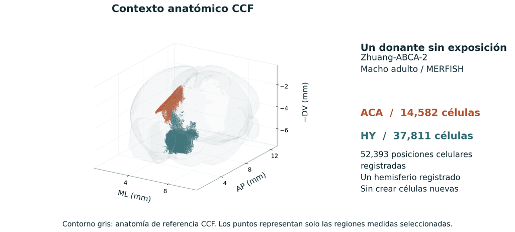

El contorno gris del cerebro completo aporta contexto anatómico. El rojizo ubica 14,582 células ACA y el verdeazulado, 37,811 HY en posiciones CCF registradas. Son 52,393 células de un donante sin exposición y un hemisferio registrado. Se localizan células sin rellenar regiones no muestreadas ni reflejar células al hemisferio opuesto.

Diapositiva interactiva de hipotálamo · Diapositiva interactiva de corteza

Análisis: este proyecto[Zhang et al., Nature 2023](https://doi.org/10.1038/s41586-023-06808-9) · [Allen CCF, 2020 annotation](https://alleninstitute.github.io/abc_atlas_access/descriptions/Allen-CCF-2020.html)

## Priorización génica y cobertura del panel medido

02 / Metodología

1. Conservar BH q y efectos regionales principales originales.
2. Ordenar por q y después símbolo fuente o ID exacto.
3. Mapear HY por símbolo fuente exacto y ACA por ID Ensembl exacto.
4. Anotar productos y funciones con registros oficiales NCBI/UniProt congelados.

**Cobertura:** se mide físicamente 1 de 11 hallazgos HY y 76 de 1,167 hallazgos ACA.

El top diez HY incluye nueve candidatos exploratorios. Los diez ACA cumplen BH q < 0.05 principal.

Referencias científicas[Zhang et al., Nature 2023](https://doi.org/10.1038/s41586-023-06808-9) · [Rajagopalan et al., JCI 2020](https://doi.org/10.1172/JCI137315) · [Zhang et al., Science 2025](https://doi.org/10.1126/science.adu4132)

## Las fracciones de detección conservan ceros medidos

02 / Metodología

$$d_{ig}=\mathbf1(c_{ig}>0),\qquad
\widehat f_{gA}=\frac{\sum_{i\in A}d_{ig}}{n_A}$$

$$b_x=\lfloor x/0.1\rfloor,\qquad b_y=\lfloor y/0.1\rfloor$$

- $A$: corte, anatomía, clase celular o casilla ocupada seleccionados.
- El denominador incluye todas las células medidas, incluidos los ceros.
- Las casillas de 0.1 × 0.1 mm se separan por corte físico.
- Las casillas vacías no están observadas. No se agrega interpolación ni una afirmación de densidad.

Referencias científicas[Zhang et al., Nature 2023](https://doi.org/10.1038/s41586-023-06808-9)

## Escenario regional uniforme con PM₂.₅

02 / Metodología

$$E_{\mathrm{escenario}}(c,g)
=E_{\mathrm{referencia}}(c,g)\,
2^{\widehat\beta^{\,\mathrm{regularizada}}_g}$$

| Ejemplo | log₂FC regional regularizado | Multiplicador |
| --- | --- | --- |
| HY / Tll1 | −1.22405 | 0.42808 |
| ACA / Fosb | +0.99711 | 1.99600 |

Se mantienen posiciones y número de células. Una escala común por gen permite comparar.

Es una propagación ilustrativa del efecto regional a una referencia sin exposición.

Referencias científicas[Zhang et al., Nature 2023](https://doi.org/10.1038/s41586-023-06808-9)

## El supuesto detrás de la comparación referencia–PM

02 / Metodología

**Entrada medida.** Cada célula conserva su coordenada y expresión de referencia originales. Las mediciones proceden de un animal sin exposición.

**Regla del escenario.** Aplicar un multiplicador regional por gen a todos los valores. Fosb recibe aproximadamente ×2 en ACA y Tll1, ×0.428 en HY. Los ceros siguen en cero y ninguna célula cambia de posición, aparece o desaparece.

**Significado científico.** Permite visualizar una estimación regional en anatomía. Múltiples respuestas celulares pueden producir el mismo efecto bulk. La regla no recupera respuestas celulares específicas ni añade resolución espacial.

Referencias científicas[Zhang et al., Science 2025](https://doi.org/10.1126/science.adu4132) · [Rajagopalan et al., JCI 2020](https://doi.org/10.1172/JCI137315) · [Zhang et al., Nature 2023](https://doi.org/10.1038/s41586-023-06808-9)

## Referencia gaussiana con bases espaciales fijas

02 / Metodología

$$y_{ig}=\ln(1+c_{ig})
=\mathbf x_i^\top\boldsymbol\beta_g+\epsilon_{ig}$$

$$\phi_j(\mathbf r)=
\exp\!\left[-\frac12\sum_k\frac{(r_k-m_{jk})^2}{\ell_k^2}\right],
\qquad\boldsymbol\ell=(0.60,0.45,0.45)\ \mathrm{mm}$$

Variables: intercepto, indicadores anatómicos, tres coordenadas CCF estandarizadas, 36 RBF anisótropas e interceptos de corte.

No se usan predictores de clase celular derivados de expresión.

Referencias científicas[Zhang et al., Nature 2023](https://doi.org/10.1038/s41586-023-06808-9) · [Murphy, 2007, Gaussian conjugacy](https://www.cs.ubc.ca/~murphyk/Papers/bayesGauss.pdf) · [Rasmussen & Williams, 2006, ch. 2](https://gaussianprocess.org/gpml/chapters/RW2.pdf)

## Priors propios y posterior analítica

02 / Metodología

$$\boldsymbol\beta\mid\sigma^2\sim
\mathcal N(0,\sigma^2V_0),\qquad \sigma^2\sim IG(3,1)$$

$$V_n=(X^\top X+V_0^{-1})^{-1},\quad
m_n=V_nX^\top y,\quad a_n=3+n/2$$

$$b_n=1+\frac12\left(y^\top y-m_n^\top V_n^{-1}m_n\right)$$

Multiplicadores de varianza previa: intercepto25, anatomía1, coordenadas0.25, cada RBF1/36 y cada corte0.25.

El cálculo Cholesky verifica ecuaciones normales y escala posterior.

Referencias científicas[Zhang et al., Nature 2023](https://doi.org/10.1038/s41586-023-06808-9) · [Murphy, 2007, Gaussian conjugacy](https://www.cs.ubc.ca/~murphyk/Papers/bayesGauss.pdf) · [Rasmussen & Williams, 2006, ch. 2](https://gaussianprocess.org/gpml/chapters/RW2.pdf)

## Cómo el prior y las mediciones forman una posterior

02 / Metodología

**Antes de las observaciones**, un prior propio restringe magnitudes de coeficientes y variación no explicada. Regulariza grupos anatómicos escasos y bases espaciales sin aportar mediciones nuevas.

**La verosimilitud** describe cómo varía la expresión medida de referencia para unos coeficientes dados. Al combinarla con el prior obtenemos una distribución posterior de parámetros plausibles.

**La predicción** propaga esa distribución a un objetivo definido. Una media posterior suave es una estimación condicional. Su utilidad científica exige comparaciones reservadas, revisión de intervalos y sensibilidad a los supuestos declarados.

Referencias científicas[Murphy, 2007, Gaussian conjugacy](https://www.cs.ubc.ca/~murphyk/Papers/bayesGauss.pdf) · [Rasmussen & Williams, 2006, ch. 2](https://gaussianprocess.org/gpml/chapters/RW2.pdf) · [SciPy, beta-binomial distribution](https://docs.scipy.org/doc/scipy/reference/generated/scipy.stats.betabinom.html)

## Intervalos creíbles y predictivos de un corte nuevo

02 / Metodología

**Media latente ajustada por corte**

$$f_*\mid y\sim t_{2a_n}\left(x_*^\top m_n,\
\sqrt{\frac{b_n}{a_n}x_*^\top V_nx_*}\right)$$

**Célula nueva en un corte físico nuevo**

$$y_*\mid y\sim t_{2a_n}\left(x_*^\top m_n,\
\sqrt{\frac{b_n}{a_n}\left(1.25+x_*^\top V_nx_*\right)}\right)$$

Los segundos argumentos son **escalas t de Student**, no varianzas.

Los mapas muestran ajuste con toda la referencia en posiciones medidas. La predicción reservada se evalúa aparte.

Referencias científicas[Zhang et al., Nature 2023](https://doi.org/10.1038/s41586-023-06808-9) · [Murphy, 2007, Gaussian conjugacy](https://www.cs.ubc.ca/~murphyk/Papers/bayesGauss.pdf) · [Rasmussen & Williams, 2006, ch. 2](https://gaussianprocess.org/gpml/chapters/RW2.pdf)

## Validación por cortes completos con separación vecina

02 / Metodología

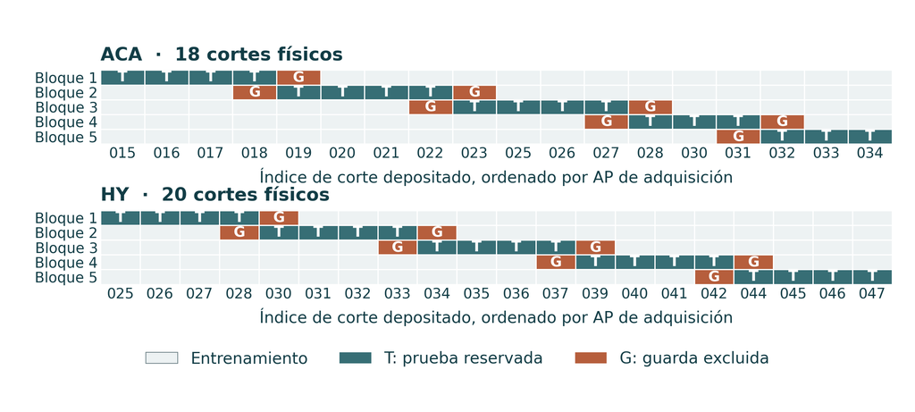

Cada fila muestra un bloque de validación sobre cortes físicos ordenados. Los cortes verdeazulados forman la evaluación, los rojizos son vecinos excluidos y los claros entrenan el modelo. Cada célula medida se evalúa una vez. Reservar cortes completos reduce filtración local, aunque todos los bloques siguen perteneciendo al mismo donante.

Análisis: este proyecto[Zhang et al., Nature 2023](https://doi.org/10.1038/s41586-023-06808-9)

## Por qué la validación reserva cortes y sus vecinos

02 / Metodología

**La pregunta predictiva** es cómo funciona el modelo en un corte físico no observado durante el ajuste. Dividir células vecinas al azar puede dejar información local muy similar en entrenamiento y evaluación.

**La separación** excluye del entrenamiento los cortes representados adyacentes al bloque evaluado. Estandarización, vocabulario anatómico y bases espaciales usan únicamente el entrenamiento restante.

**La comparación** utiliza los mismos bloques para modelos espaciales y referencias simples. Ajustar mejor el atlas completo no sustituye predecir mejor datos reservados. Se evalúa transferencia dentro de un donante y quedan pendientes otros donantes y exposición.

Referencias científicas[Zhang et al., Nature 2023](https://doi.org/10.1038/s41586-023-06808-9) · [Murphy, 2007, Gaussian conjugacy](https://www.cs.ubc.ca/~murphyk/Papers/bayesGauss.pdf) · [SciPy, beta-binomial distribution](https://docs.scipy.org/doc/scipy/reference/generated/scipy.stats.betabinom.html)

## Modelo jerárquico de probabilidad de detección acotada

02 / Metodología

$$Y_{sag}\mid p_{sag}\sim
\operatorname{Binomial}(n_{sa},p_{sag})$$

$$p_{sag}\mid\mu_{ag},\kappa_{ag}\sim
\operatorname{Beta}(\mu_{ag}\kappa_{ag},(1-\mu_{ag})\kappa_{ag})$$

$$\mu_{ag}\sim\operatorname{Beta}(0.5,0.5),\qquad
\ln\kappa_{ag}\sim\mathcal N(\ln20,1.5^2)$$

Se ajustan genes/anatomías por separado. Las propensiones de corte son intercambiables dentro de cada ajuste. Las probabilidades permanecen entre 0 y 1.

Referencias científicas[Zhang et al., Nature 2023](https://doi.org/10.1038/s41586-023-06808-9) · [SciPy, beta-binomial distribution](https://docs.scipy.org/doc/scipy/reference/generated/scipy.stats.betabinom.html)

## Integración por cuadrícula y cálculo de incertidumbre

02 / Metodología

- Cuadrícula principal: **64 μ × 48 κ cuantiles previos**, con pesos iguales.
- Normalizar pesos de log-verosimilitud beta-binomial con log-sum-exp.
- Intervalos de μ: cuantiles ponderados de la cuadrícula discreta.
- Intervalos de p conocido y conteo reservado: **8,192 sorteos de mezcla con semilla**.
- Intervalos de p de un corte nuevo con referencia completa: inversión numérica de la CDF de mezcla Beta.
- Revisar 32 × 24 y 96 × 64 sin seleccionar por desempeño reservado.

Referencias científicas[Zhang et al., Nature 2023](https://doi.org/10.1038/s41586-023-06808-9) · [SciPy, beta-binomial distribution](https://docs.scipy.org/doc/scipy/reference/generated/scipy.stats.betabinom.html)

## Tres objetivos distintos de incertidumbre de detección

02 / Metodología

| Objetivo | Condicionamiento | Interpretación |
| --- | --- | --- |
| $p_{sa}$ de corte conocido | Positivas y denominador observados | Intervalo creíble del corte ajustado |
| Media anatómica $\mu_a$ | Información de cortes intercambiables | Intervalo creíble de la hipermedia |
| $p_*$ o $Y_*$ de corte nuevo | Sin conteos de ese corte nuevo | Distribución predictiva de propensión o conteo |

Una anatomía reservada ausente del entrenamiento queda **solo con prior** y se conserva en evaluación.

Un intervalo ajustado conocido no es una predicción reservada.

Referencias científicas[Zhang et al., Nature 2023](https://doi.org/10.1038/s41586-023-06808-9) · [SciPy, beta-binomial distribution](https://docs.scipy.org/doc/scipy/reference/generated/scipy.stats.betabinom.html)

## Distintos intervalos responden distintas preguntas de detección

02 / Metodología

**Un corte conocido:** tras observar sus positivas y el denominador total, estimamos la probabilidad subyacente de ese corte. Su intervalo creíble está condicionado por esas observaciones.

**Una media anatómica:** combinamos información de cortes intercambiables para estimar la propensión típica de esa anatomía. Esta hipermedia tiene su propio intervalo creíble.

**Un corte nuevo:** predecimos su propensión antes de ver sus conteos, o el número de positivas para un denominador definido. La heterogeneidad entre cortes y, en conteos, la variación de muestreo entran en la predicción. Hay que identificar el objetivo antes de comparar amplitud o cobertura.

Referencias científicas[Zhang et al., Nature 2023](https://doi.org/10.1038/s41586-023-06808-9) · [SciPy, beta-binomial distribution](https://docs.scipy.org/doc/scipy/reference/generated/scipy.stats.betabinom.html)

## Métricas predictivas y comparación con referencias

02 / Metodología

$$\operatorname{RMSE}=
\sqrt{\frac1N\sum_i(y_i-\widehat y_i)^2}$$

$$\operatorname{Brier}=
\frac{\sum_j[Y_j(1-\widehat p_j)^2+
(n_j-Y_j)\widehat p_j^2]}{\sum_j n_j}$$

Referencia gaussiana: comparar regresión de solo anatomía y predicción con30 vecinos.

Referencia de detección: colapsar anatomía en cada corte permitido de entrenamiento.

Informar cobertura reservada **junto con amplitud**. Menor pérdida predictiva es mejor.

Referencias científicas[Zhang et al., Nature 2023](https://doi.org/10.1038/s41586-023-06808-9) · [Murphy, 2007, Gaussian conjugacy](https://www.cs.ubc.ca/~murphyk/Papers/bayesGauss.pdf) · [SciPy, beta-binomial distribution](https://docs.scipy.org/doc/scipy/reference/generated/scipy.stats.betabinom.html)

## Resultados reconstruidos de los estudios originales

03 / Reproducción de autores

Recuperación exacta de salidas, sensibilidad metodológica parcial y concordancia condicional

## Se recuperan exactamente los conjuntos corticales significativos

03 / Reproducción de autores

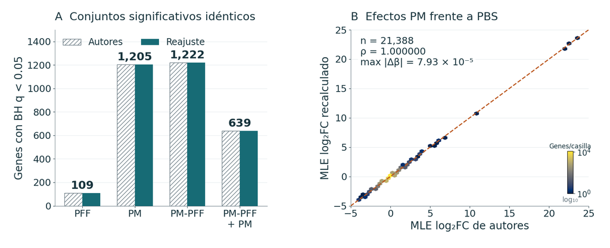

Las barras recuperan 109 / 1,205 / 1,222 / 639 genes significativos en los cuatro contrastes originales. Los efectos coinciden con la línea de identidad. Todos los Jaccard son 1: se recuperan las salidas numéricas desde conteos depositados. Se reutilizan los animales fuente, por lo que la concordancia no añade replicación biológica independiente.

Análisis: este proyecto[Zhang et al., Science 2025](https://doi.org/10.1126/science.adu4132)

## La salida reproducible conserva una pregunta de calidad

03 / Reproducción de autores

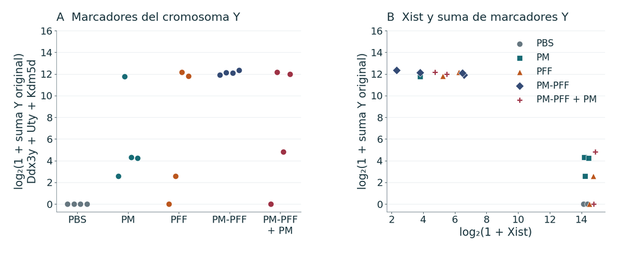

Los puntos conservan los 20 animales fuente. Los cuatro controles PBS tienen cero conteos Ddx3y, Uty y Kdm5d, mientras los otros grupos varían. La comparación con Xist añade otra vista descriptiva. El patrón motiva verificar sexo e identidad originales, sin asignar sexo ni demostrar confusión solo mediante expresión.

Análisis: este proyecto[Zhang et al., Science 2025](https://doi.org/10.1126/science.adu4132)

## La comparación hipotalámica conserva sensibilidad metodológica

03 / Reproducción de autores

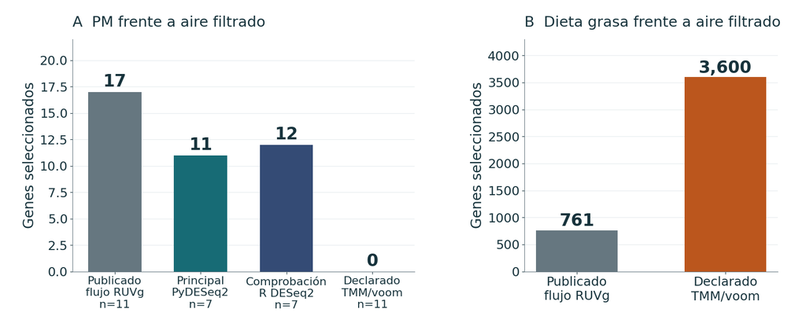

Las listas originales contienen 17 genes PM y 761 HFD. La sensibilidad TMM/voom devuelve 0 y 3,600 bajo otros criterios declarados. Se muestran aparte el análisis principal de siete animales y su comprobación en R. Faltan especificaciones RUVg para reconstruir exactamente: los conteos describen sensibilidad metodológica, sin demostrar ausencia de replicación biológica.

Análisis: este proyecto[Rajagopalan et al., JCI 2020](https://doi.org/10.1172/JCI137315)

## La dirección de miR-574-5p coincide sin confirmación BH

03 / Reproducción de autores

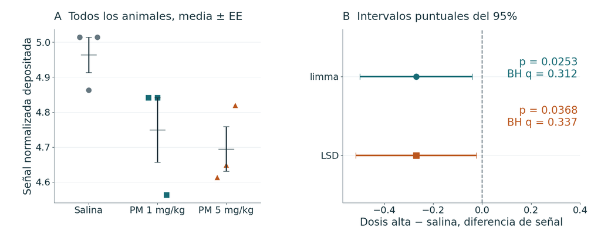

Los puntos muestran menor señal miR-574-5p a dosis alta, con diferencia de −0.26945 unidades depositadas. El intervalo limma nominal excluye cero, pero p = 0.0253 pasa a BH q = 0.312 en el array. ANOVA p = 0.0788 impide LSD protegido. La coincidencia direccional no alcanza confirmación con ajuste de multiplicidad.

Análisis: este proyecto[Ku et al., Part. Fibre Toxicol. 2017](https://doi.org/10.1186/s12989-017-0215-3) · [Ritchie et al., NAR 2015](https://doi.org/10.1093/nar/gkv007)

## Los efectos de genotipo en ozono muestran concordancia condicional

03 / Reproducción de autores

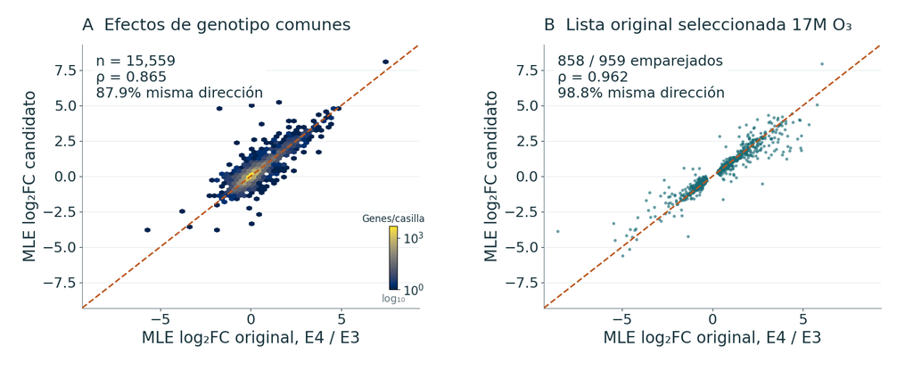

El umbral depositado de genotipo recupera exactamente 2,501 genes. La correlación de efectos finitos comunes es ρ = 0.865. La lista S3 seleccionada alcanza ρ = 0.962 y 98.8% de concordancia direccional entre efectos cotejados. Su selección previa y los mismos animales impiden interpretar esa mayor concordancia como replicación transcriptómica global no sesgada.

Análisis: este proyecto[Nakamya et al., IJMS 2025](https://doi.org/10.3390/ijms26062407)

## Las conclusiones de reproducción difieren entre estudios

03 / Reproducción de autores

| Estudio | Resultado defendible | Límite pendiente |
| --- | --- | --- |
| Corteza | Cuatro conjuntos y PCA del código exactos | Sin flujo de lecturas completo ni sexo/identidad resueltos |
| Hipotálamo | Sensibilidad TMM/voom declarada | Sin controles RUVg ni k |
| miRNA | Dirección y evidencia nominal no protegida | Ómnibus y BH del array no confirman el objetivo |
| Ozono | Selección exacta de tabla y efectos cotejados | Otro cuantificador y condicionamiento por selección |

Referencias científicas[Rajagopalan et al., JCI 2020](https://doi.org/10.1172/JCI137315) · [Zhang et al., Science 2025](https://doi.org/10.1126/science.adu4132) · [Nakamya et al., IJMS 2025](https://doi.org/10.3390/ijms26062407)

## Análisis nuevos dentro del proyecto

04 / Resultados del proyecto

Reanálisis principal, heterogeneidad de respuesta, conjuntos génicos y modelado de referencia espacial

## El análisis HY principal identifica 11 hallazgos BH

04 / Resultados del proyecto

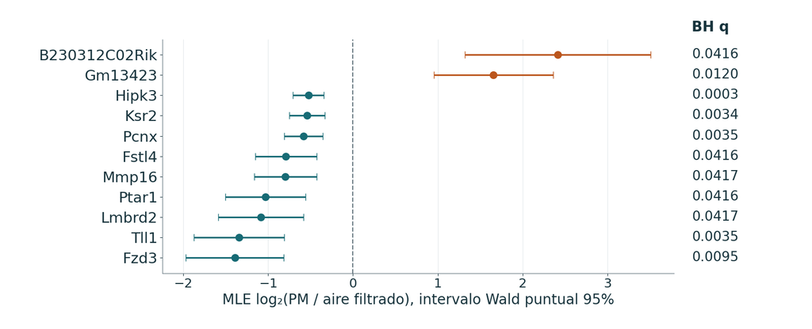

Con 4 animales de aire filtrado y 3 PM, el modelo identifica 11 hallazgos BH: dos mayores y nueve menores. Los puntos son log₂ fold changes MLE y las barras, intervalos Wald puntuales del 95%. La dirección corresponde al contraste regional, sin intervalos simultáneos ni evidencia de un cambio equivalente en cada célula espacial.

Análisis: este proyecto[Rajagopalan et al., JCI 2020](https://doi.org/10.1172/JCI137315)

## El análisis cortical principal usa ocho animales PM/PBS

04 / Resultados del proyecto

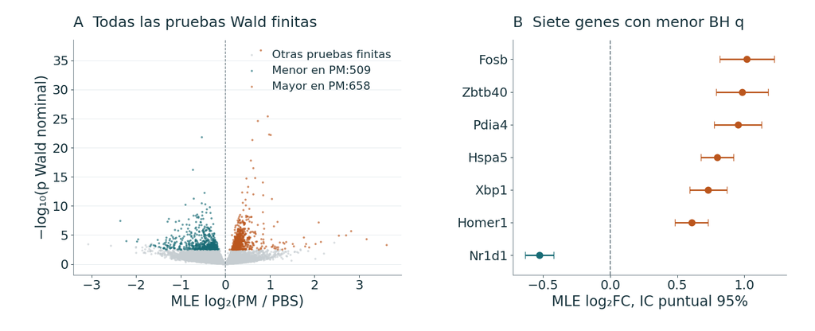

El volcán separa magnitud del efecto y evidencia Wald nominal. Los colores identifican hallazgos BH. Los siete genes con menor q tienen intervalos MLE puntuales. El contraste principal de ocho animales produce 1,167 hallazgos: 658 mayores y 509 menores. Su población y modelo difieren de la reconstrucción de 20 animales con 1,205 genes PM.

Análisis: este proyecto[Zhang et al., Science 2025](https://doi.org/10.1126/science.adu4132)

## El análisis miRNA nuevo conserva toda la familia de pruebas

04 / Resultados del proyecto

1 / 0

hallazgos BH a dosis baja / alta

| Contraste | Características | Hallazgos BH | Escala |
| --- | --- | --- | --- |
| PM 1 mg/kg frente a control | 1,245 | 1 mayor | Diferencia original de señal |
| PM 5 mg/kg frente a control | 1,245 | 0 | Diferencia original de señal |
| F ómnibus separada | 1,245 | 1 | Diferencia conjunta de condición |

El hallazgo de dosis baja es mmu-miR-5119. Se muestran indicadores de baja detección y no se excluye ningún array.

Análisis: este proyecto[Ku et al., Part. Fibre Toxicol. 2017](https://doi.org/10.1186/s12989-017-0215-3) · [Ritchie et al., NAR 2015](https://doi.org/10.1093/nar/gkv007)

## Los hallazgos de ozono dependen del estrato y la prueba

04 / Resultados del proyecto

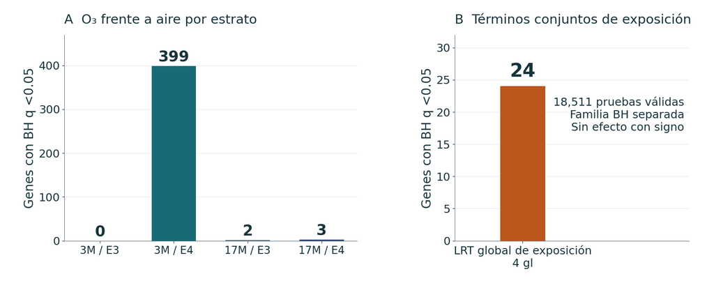

BH por estrato produce 0 / 399 / 2 / 3 genes en el orden edad inicial/APOE 3M/E3, 3M/E4, 17M/E3 y 17M/E4. El LRT conjunto de exposición con 4 grados de libertad encuentra 24 genes en otra familia de pruebas. Los conteos reflejan evidencia y precisión, sin establecer por sí solos una interacción.

Análisis: este proyecto[Nakamya et al., IJMS 2025](https://doi.org/10.3390/ijms26062407)

## La respuesta dependiente de edad tiene la señal conjunta más clara

04 / Resultados del proyecto

08

genes de respuesta por edad; 1 con BH conjunta

| LRT conjunto secundario | gl | Hallazgos BH por familia | BH conjunta tres familias |
| --- | --- | --- | --- |
| Respuesta dependiente de genotipo | 2 | 0 | 0 |
| Respuesta dependiente de edad | 2 | 8 | 1 |
| Interacción triple | 1 | 0 | 0 |

Genes de respuesta por edad: Ryr3, Rps24, Pkig, Rpl26, Inpp5d, Stk11, Rpl34 y Gm21586.

Análisis: este proyecto[Nakamya et al., IJMS 2025](https://doi.org/10.3390/ijms26062407) · [Love et al., Genome Biol. 2014](https://doi.org/10.1186/s13059-014-0550-8)

## Los perfiles animales contextualizan diferencias de respuesta

04 / Resultados del proyecto

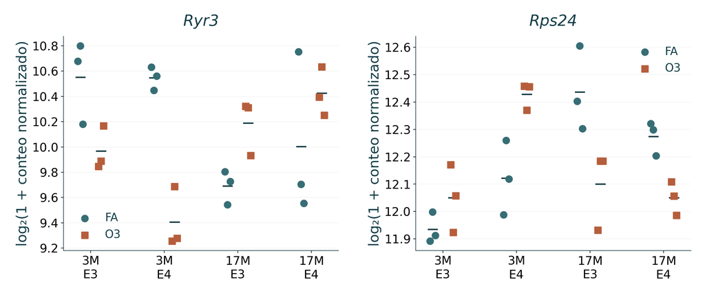

Cada gen conserva los 24 animales secuenciados, agrupados por edad inicial, APOE y exposición. Los puntos representan log₂(1 + conteo normalizado) y los segmentos, medias descriptivas. Ryr3 y Rps24 pertenecen a los ocho hallazgos LRT dependientes de edad. El desplazamiento horizontal separa símbolos, mientras el modelo factorial aporta la prueba de interacción.

Análisis: este proyecto[Nakamya et al., IJMS 2025](https://doi.org/10.3390/ijms26062407)

## ORA y GSEA por rango describen evidencia diferente

04 / Resultados del proyecto

| Contraste | Términos ORA mayores / menores | Términos FDR algorítmica GSEA |
| --- | --- | --- |
| HY | 0 / 0 | 916 |
| ACA | 86 / 2 | 223 |
| O₃ M3_E3 | 0 / 0 | 4 |
| O₃ M3_E4 | 0 / 0 | 368 |
| O₃ M17_E3 | 0 / 0 | 85 |
| O₃ M17_E4 | 0 / 0 | 23 |

Estos términos correlacionados no cuentan mecanismos biológicos independientes.

Análisis: este proyecto[Subramanian et al., PNAS 2005](https://doi.org/10.1073/pnas.0506580102) · [Gene Ontology Consortium](https://geneontology.org/docs/go-enrichment-analysis/)

## Patrones GO seleccionados en seis contrastes de ARN

04 / Resultados del proyecto

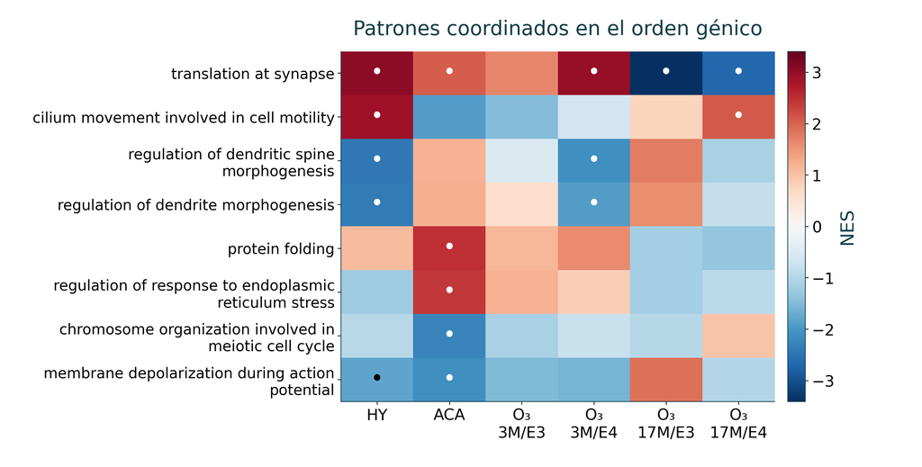

El color muestra NES con signo en una escala común y los puntos indican FDR algorítmica GSEA < 0.05. Gris significa no elegible o no disponible. Son los primeros ocho términos de una selección gráfica de 22. La correlación y selección de anotaciones impiden leer la matriz como mecanismos independientes o actividad exhaustiva de vías.

Análisis: este proyecto[Subramanian et al., PNAS 2005](https://doi.org/10.1073/pnas.0506580102) · [Gene Ontology Consortium](https://geneontology.org/docs/go-enrichment-analysis/)

## Los productos génicos contextualizan sin medir proteínas

04 / Resultados del proyecto

| Gen | Producto / función anotada | Panel medido |
| --- | --- | --- |
| [Tll1](https://www.ncbi.nlm.nih.gov/gene/21892) | Proteasa extracelular de procesamiento tolloid-like | Sí |
| [Fosb](https://www.ncbi.nlm.nih.gov/gene/14282) | FosB, subunidad del factor transcripcional AP-1 | Sí |
| [S1pr1](https://www.ncbi.nlm.nih.gov/gene/13609) | Receptor de esfingosina-1-fosfato | Sí |
| [Hspa5](https://www.ncbi.nlm.nih.gov/gene/14828) | Chaperona BiP/GRP78 del retículo endoplásmico | No |
| [Ksr2](https://www.ncbi.nlm.nih.gov/gene/333050) | Andamio RAF–MEK/MAPK | No |
| [C730002L08Rik](https://www.ncbi.nlm.nih.gov/gene/320155) | ARN no codificante, sin proteína anotada | Sí |

Análisis: este proyecto[NCBI Gene: Tll1](https://www.ncbi.nlm.nih.gov/gene/21892) · [UniProtKB: Tll1](https://www.uniprot.org/uniprotkb/Q62381/entry) · [Zhang et al., Nature 2023](https://doi.org/10.1038/s41586-023-06808-9)

## Las capas corticales medidas organizan las células de referencia

04 / Resultados del proyecto

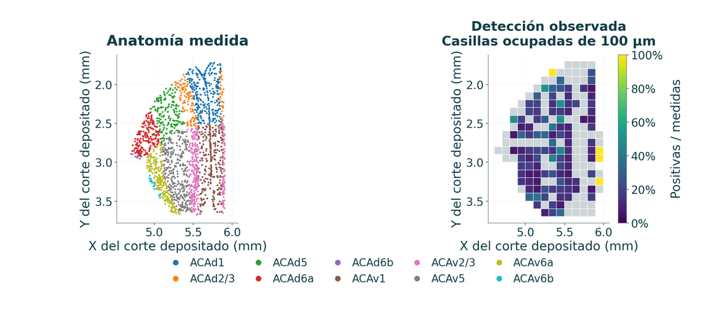

El mayor corte ACA contiene 1,940 células medidas. A la izquierda, posiciones depositadas y etiquetas anatómicas muestran capas corticales. A la derecha, cada casilla ocupada de 100 µm divide células Fosb positivas por todas las medidas, incluidos ceros. Las casillas vacías siguen sin observarse. Describe un donante sin exposición, sin estimar efectos PM por capa.

Análisis: este proyecto[Zhang et al., Nature 2023](https://doi.org/10.1038/s41586-023-06808-9)

## Núcleos hipotalámicos medidos y detección Tll1

04 / Resultados del proyecto

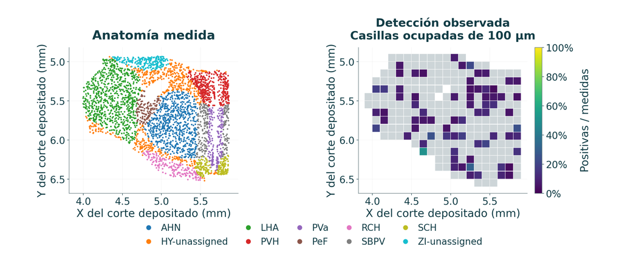

El mayor corte HY contiene 3,565 células medidas. Las etiquetas anatómicas organizan posiciones depositadas y las casillas ocupadas muestran positivas/todas. En HY completo, Tll1 se detecta en 667 de 37,811 células: 1.764%. La detección escasa puede reflejar biología y sensibilidad del ensayo, sin distinguir ambas explicaciones con estos datos solos.

Análisis: este proyecto[Zhang et al., Nature 2023](https://doi.org/10.1038/s41586-023-06808-9)

## El escalamiento ilustrativo preserva la geometría medida

04 / Resultados del proyecto

**ACA / Fosb:** el efecto bulk regularizado produce un escenario cercano al doble.

**HY / Tll1:** el efecto bulk regularizado produce un escenario de 0.428 veces.

- Cada valor positivo recibe el mismo multiplicador regional de su gen.
- Los ceros, las posiciones y la cantidad de células se mantienen.
- La interfaz vincula candidatos medidos, productos génicos, resultados de animales fuente e incertidumbre.

[Abrir el visor cortical 3D emparejado](https://amarusimonaguerojimenez.github.io/Air-Pollution-Brain-Omics-Mouse/es/cortex_viewer.html).

Análisis: este proyecto[Zhang et al., Nature 2023](https://doi.org/10.1038/s41586-023-06808-9)

## Hipotálamo: referencia interactiva y escenario PM₂.₅

04 / Resultados del proyecto

Cargando mapa interactivo…

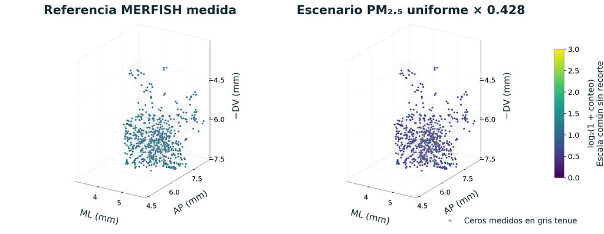

La izquierda muestra conteos Tll1 medidos. La derecha multiplica cada valor por 0.42808 e ilustra el efecto regional regularizado. Ambos paneles conservan 37,811 posiciones y las mismas 667 células positivas. La escala común muestra el cambio de magnitud. El gráfico no identifica respuestas celulares específicas a la exposición ni infiere pérdida celular.

[interactive chart not shown]

Arrastre un mapa para rotar ambas escenas. Seleccione un gen medido y aplíquelo. Los paneles conservan las mismas células registradas. PM₂.₅ aplica un multiplicador regional, sin identificar respuestas celulares específicas a la exposición.

Análisis: este proyecto[Rajagopalan et al., JCI 2020](https://doi.org/10.1172/JCI137315) · [Zhang et al., Nature 2023](https://doi.org/10.1038/s41586-023-06808-9)

## Corteza: referencia interactiva y escenario PM₂.₅

04 / Resultados del proyecto

Cargando mapa interactivo…

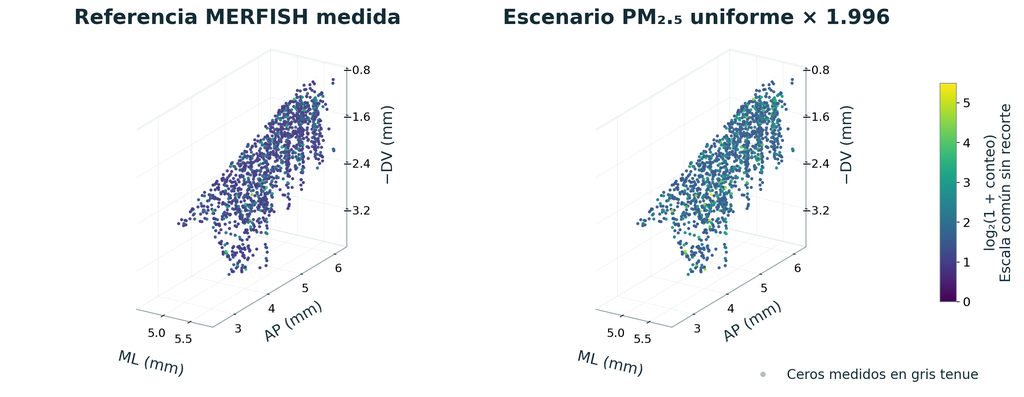

La izquierda muestra conteos Fosb medidos. La derecha aplica el multiplicador regional de 1.996 a esa referencia. Se mantienen 14,582 posiciones y 1,418 células positivas, con escala de color común completa. El escenario más intenso ilustra un efecto bulk, sin establecer qué capas o tipos celulares corticales responden a PM₂.₅.

[interactive chart not shown]

Arrastre un mapa para rotar ambas escenas. Seleccione un gen medido y aplíquelo. Los paneles conservan las mismas células registradas. PM₂.₅ aplica un multiplicador regional, sin identificar respuestas celulares específicas a la exposición.

Análisis: este proyecto[Zhang et al., Science 2025](https://doi.org/10.1126/science.adu4132) · [Zhang et al., Nature 2023](https://doi.org/10.1038/s41586-023-06808-9)

## La regresión gaussiana espacial mejora pocas veces la referencia

04 / Resultados del proyecto

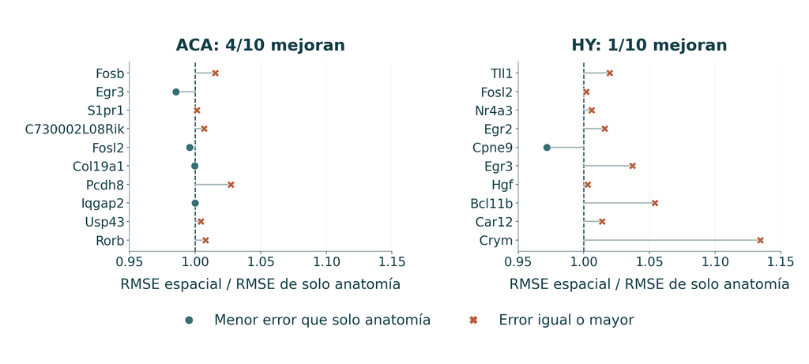

Cada punto compara RMSE del modelo espacial con RMSE anatómico en los mismos cortes reservados. Una razón menor que 1 favorece al modelo espacial: mejora 4/10 genes ACA y 1/10 HY. Coordenadas y bases aportan beneficio limitado. Un mapa suavizado ajustado con toda la referencia no mostraría por sí solo esta limitación predictiva.

Análisis: este proyecto[Zhang et al., Nature 2023](https://doi.org/10.1038/s41586-023-06808-9) · [Murphy, 2007, Gaussian conjugacy](https://www.cs.ubc.ca/~murphyk/Papers/bayesGauss.pdf)

## La cobertura global oculta limitaciones gaussianas importantes

04 / Resultados del proyecto

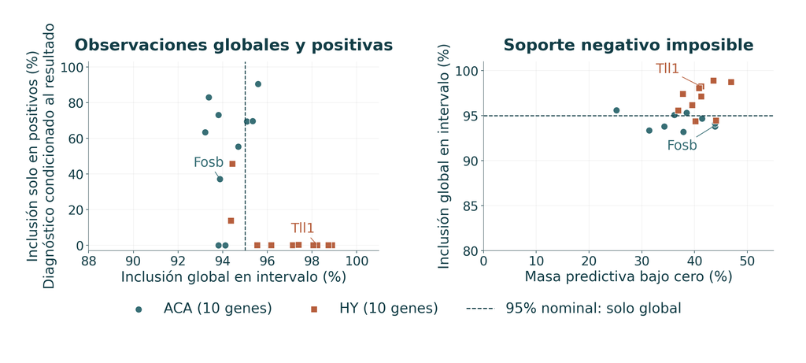

A la izquierda, la inclusión global puede ser alta con mala inclusión entre observaciones positivas. La inclusión solo en positivas es un diagnóstico condicional, sin objetivo nominal del 95%. A la derecha, la predicción gaussiana asigna masa bajo cero en log(1 + conteo), un rango imposible. Ambos diagnósticos revelan límites ocultos por la cobertura marginal.

Análisis: este proyecto[Zhang et al., Nature 2023](https://doi.org/10.1038/s41586-023-06808-9) · [Murphy, 2007, Gaussian conjugacy](https://www.cs.ubc.ca/~murphyk/Papers/bayesGauss.pdf)

## La detección acotada mejora modestamente en ACA y falla en HY

04 / Resultados del proyecto

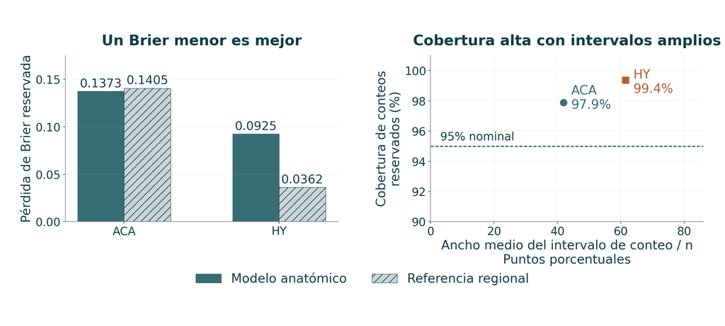

Menor Brier favorece al modelo. ACA mejora modestamente: 0.13725 frente a 0.14051. HY empeora: 0.09246 frente a 0.03621. El gráfico cobertura–amplitud muestra cobertura predictiva alta con intervalos amplios. Se conservan grupos anatómicos sostenidos solo por el prior, de modo que acotar probabilidades no establece precisión ni transferencia predictiva.

Análisis: este proyecto[Zhang et al., Nature 2023](https://doi.org/10.1038/s41586-023-06808-9) · [SciPy, beta-binomial distribution](https://docs.scipy.org/doc/scipy/reference/generated/scipy.stats.betabinom.html)

## La calidad predictiva depende de error, cobertura y soporte

04 / Resultados del proyecto

**Error predictivo.** El modelo acotado tiene Brier ligeramente menor que la referencia regional en ACA. En HY, la evaluación completa es peor que la referencia.

**Soporte del entrenamiento.** Por cada gen HY, 79 de 186 grupos corte–anatomía reservados tienen etiquetas anatómicas ausentes del entrenamiento. Sus predicciones dependen solo del prior declarado y permanecen en la puntuación.

**Incertidumbre.** Intervalos amplios pueden cubrir numerosos resultados con poca precisión. Acotar probabilidades, integrar de forma estable y mostrar mapas plausibles no demuestra por sí solo predicción útil ni mayor resolución espacial.

Análisis: este proyecto[Zhang et al., Nature 2023](https://doi.org/10.1038/s41586-023-06808-9) · [Murphy, 2007, Gaussian conjugacy](https://www.cs.ubc.ca/~murphyk/Papers/bayesGauss.pdf) · [SciPy, beta-binomial distribution](https://docs.scipy.org/doc/scipy/reference/generated/scipy.stats.betabinom.html)

## La detección posterior ACA separa objetivos de incertidumbre

04 / Resultados del proyecto

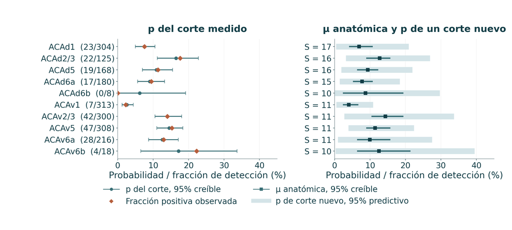

Para Fosb, el panel izquierdo compara fracciones observadas y probabilidades posteriores del corte conocido. El derecho separa intervalos creíbles de la media anatómica y predicciones de propensión de un corte nuevo. El intervalo claro expresa variación entre cortes y estima otro objetivo que el oscuro. Describen un donante sin exposición. La validación reserva cortes.

Análisis: este proyecto[Zhang et al., Nature 2023](https://doi.org/10.1038/s41586-023-06808-9) · [SciPy, beta-binomial distribution](https://docs.scipy.org/doc/scipy/reference/generated/scipy.stats.betabinom.html)

## La anatomía HY ajustada no garantiza predicción reservada

04 / Resultados del proyecto

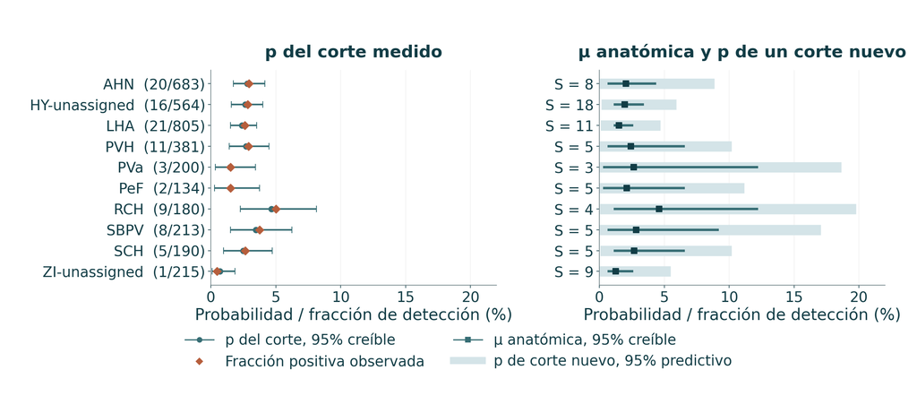

Para Tll1, las probabilidades ajustadas permanecen entre 0 y 1 pese a detecciones escasas. La media anatómica y la propensión de corte nuevo tienen incertidumbres distintas. Un mapa puede parecer plausible aunque falte anatomía en entrenamiento. La evaluación HY conserva esos grupos y hace visible la dependencia del prior mediante el error predictivo.

Análisis: este proyecto[Zhang et al., Nature 2023](https://doi.org/10.1038/s41586-023-06808-9) · [SciPy, beta-binomial distribution](https://docs.scipy.org/doc/scipy/reference/generated/scipy.stats.betabinom.html)

## Estabilidad numérica y utilidad predictiva son distintas

04 / Resultados del proyecto

| Cuadrícula 64×48 frente a 96×64 | ACA | HY |
| --- | --- | --- |
| Cambio máximo de media μ | 0.000192 | 0.000537 |
| Cambio máximo de extremo IC de μ | 0.0203 | 0.0181 |
| Cambio máximo de extremo p nuevo | 0.00254 | 0.00358 |
| Cobertura reservada de conteos | 97.89% → 98.05% | 99.35% sin cambio |

Las verificaciones numéricas y de simulación reproducible apoyan la revisión computacional. No reparan una predicción débil ni validan biológicamente los priors.

Análisis: este proyecto[Zhang et al., Nature 2023](https://doi.org/10.1038/s41586-023-06808-9) · [Murphy, 2007, Gaussian conjugacy](https://www.cs.ubc.ca/~murphyk/Papers/bayesGauss.pdf) · [SciPy, beta-binomial distribution](https://docs.scipy.org/doc/scipy/reference/generated/scipy.stats.betabinom.html)

## Límites que cambian la interpretación científica

05 / Interpretación

| Nivel | Inferencia respaldada | Límite |
| --- | --- | --- |
| Reproducción | Recuperación numérica con datos fuente | Sin réplicas biológicas nuevas |
| Bulk / miRNA | Asociaciones regionales de cada estudio | Composición, n pequeño y metadatos |
| GO e interacciones | Patrones exploratorios / contrastes definidos | Multiplicidad, correlación y supuestos |
| Atlas medido | Detección en posiciones originales | Un donante, panel dirigido y espacios entre cortes |
| Bayesianos espaciales | Estimaciones condicionales y diagnósticos reservados | Ganancia limitada, prior y modelo inadecuado |
| Escenario PM₂.₅ | Ilustración uniforme de efecto grupal | Sin respuesta celular identificada |

Referencias científicas[Rajagopalan et al., JCI 2020](https://doi.org/10.1172/JCI137315) · [Zhang et al., Science 2025](https://doi.org/10.1126/science.adu4132) · [Nakamya et al., IJMS 2025](https://doi.org/10.3390/ijms26062407)

## Conclusiones respaldadas por el trabajo completado

05 / Interpretación

04

conclusiones respaldadas por evidencia

1. La reconstrucción cortical recupera los cuatro conjuntos significativos y conserva una pregunta sobre la calidad de la fuente.
2. Los reanálisis muestran sensibilidad al modelo, a la familia de pruebas y al tamaño muestral. La respuesta de ozono dependiente de edad ofrece la señal conjunta más clara.
3. Los cortes medidos, los productos génicos y los modelos de detección acotada mejoran la interpretación del atlas.
4. La validación espacial informa ganancias limitadas y fallos. El trabajo no establece una reconstrucción celular de cerebro expuesto.

Referencias científicas[Rajagopalan et al., JCI 2020](https://doi.org/10.1172/JCI137315) · [Zhang et al., Science 2025](https://doi.org/10.1126/science.adu4132) · [Nakamya et al., IJMS 2025](https://doi.org/10.3390/ijms26062407)

## El trabajo futuro requiere información biológica independiente

05 / Interpretación

SIGUE

validación biológica independiente

- Recuperar los metadatos fuente de sexo/identidad y las especificaciones RUVg faltantes.
- Validar candidatos en animales y poblaciones celulares independientes.
- Evaluar modelos de conteos dispersos o hurdle y predicción entre donantes.
- Obtener mediciones espaciales/single-cell con exposición antes de inferir respuestas específicas.
- Explorar UCSC Genome Browser, Ensembl y ENCODE para evidencia epigenómica cerebral compatible.

## Reproducibilidad y discusión

05 / Interpretación

**Evidencia completa:** correspondencias con las fuentes, poblaciones analíticas, código, referencias congeladas, tablas y figuras bilingües.

**Controles:** flechas para navegar, Esc para la vista general, Notas para la explicación detallada y cambio de idioma en la misma diapositiva.

[Informe científico](https://amarusimonaguerojimenez.github.io/Air-Pollution-Brain-Omics-Mouse/es/) · [Repositorio](https://github.com/AmaruSimonAgueroJimenez/Air-Pollution-Brain-Omics-Mouse)

El apéndice contiene protocolos, fórmulas, análisis de sensibilidad, listas de candidatos y referencias.

## Apéndice técnico

06 / Apéndice técnico

Protocolos, familias de pruebas, definición de priors y reproducibilidad

## Los protocolos de PM₂.₅ permanecen diferenciados

06 / Apéndice técnico

| Brazo | Contexto inicial | Protocolo | Precaución temporal |
| --- | --- | --- | --- |
| HY / GSE145840 | C57BL/6J macho, 3 semanas | 60–120 µg/m³, media 80; 6 h/día, 5 días/semana, 14 semanas | Edad terminal e intervalo hasta la toma de tejido no informados |
| ACA / GSE297423 | hWT αSyn, 2 meses, sexo no informado | 2 µL de 5 mg/mL intranasal, cada 2 días por 2 meses | Distinto del brazo convencional de mayor edad |
| miRNA / GSE93967 | C57BL/6 macho, aprox. 8 semanas | 1 o 5 mg/kg por aspiración orofaríngea, días alternos por 4 semanas | Toma de tejido 18 h tras la dosis final |

Referencias científicas[Rajagopalan et al., JCI 2020](https://doi.org/10.1172/JCI137315) · [Zhang et al., Science 2025](https://doi.org/10.1126/science.adu4132) · [Ku et al., Part. Fibre Toxicol. 2017](https://doi.org/10.1186/s12989-017-0215-3)

## Protocolo de ozono y tamaño muestral secuenciado

06 / Apéndice técnico

- Ratones machos de reemplazo dirigido APOE3/APOE4 humano.
- Inicio de exposición a los 3 o 17 meses.
- **0.8 ppm O₃, 7 h/día por 5 días**, seguidos de 9 días con aire filtrado.
- Ocho ciclos. RNA-seq del hipocampo izquierdo.
- Los 14–16 animales/grupo del artículo difieren de **tres secuenciados por estrato**.
- Una cadena de cepa SDRF difiere en Sample1 / ERR14708304.

Referencias científicas[Nakamya et al., IJMS 2025](https://doi.org/10.3390/ijms26062407)

## Mediana de cocientes y offsets de longitud

06 / Apéndice técnico

$$G_g=\left(\prod_i K_{gi}\right)^{1/m},\qquad
s_i=\operatorname{median}_{g}\left(\frac{K_{gi}}{G_g}\right)$$

Para genes con media geométrica utilizable:

Los conteos PM normalizados son $K_{gi}/s_i$. Los factores se estiman con el universo retenido.

Ozono usa normalización gen/muestra por longitud efectiva con tximport. TPM no sustituye la entrada binomial negativa.

VST/PCA y heatmaps estandarizados por fila son transformaciones descriptivas, separadas de la verosimilitud.

Referencias científicas[Love et al., Genome Biol. 2014](https://doi.org/10.1186/s13059-014-0550-8) · [Soneson et al. 2015](https://doi.org/10.12688/f1000research.7563.2) · [Rajagopalan et al., JCI 2020](https://doi.org/10.1172/JCI137315)

## Moderación Bayes empírica en limma

06 / Apéndice técnico

$$s_{f,\mathrm{post}}^2=
\frac{d_0s_{0f}^2+d_fs_f^2}{d_0+d_f}$$

$$t_{f,\mathrm{mod}}=
\frac{\widehat\Delta_f}{s_{f,\mathrm{post}}\sqrt{v_f}}$$

La tendencia de varianza previa depende del nivel de señal. La moderación comparte información entre características.

Los intervalos t puntuales y BH entre características responden preguntas diferentes.

No se inventa pareamiento o lote para los nueve arrays.

Referencias científicas[Ritchie et al., NAR 2015](https://doi.org/10.1093/nar/gkv007) · [Ku et al., Part. Fibre Toxicol. 2017](https://doi.org/10.1186/s12989-017-0215-3)

## Familias de multiplicidad y listas no anidadas

06 / Apéndice técnico

| Ejemplo | Familia | Hallazgos BH |
| --- | --- | --- |
| Pruebas O₃ por estrato | Cada estrato separado | 0 / 399 / 2 / 3 |
| Pruebas O₃ por estrato | Cuatro familias válidas juntas | 1 / 43 / 4 / 6 |
| LRT exposición por edad | Familia propia de genes | 8 |
| Tres LRT secundarios | Pruebas válidas agrupadas | 1 hallazgo por edad |

BH conjunta ajusta otra colección de valores p. No se elige la lista que maximiza los hallazgos.

Referencias científicas[Nakamya et al., IJMS 2025](https://doi.org/10.3390/ijms26062407) · [Love et al., Genome Biol. 2014](https://doi.org/10.1186/s13059-014-0550-8)

## Sensibilidad a software y omisión de animales

06 / Apéndice técnico

| Verificación HY | Resultado guardado |
| --- | --- |
| Hallazgos BH PyDESeq2 frente a R | 11 frente a 12 |
| Correlación Pearson de efectos | 0.9999999996 |
| Acuerdo de estado Cook | Los 19,611 genes retenidos |
| Gen discordante en umbral BH | Tnrc6c: Python 0.05211, R 0.03992 |
| Rango de hallazgos leave-one-out | 0–825 |
| Dirección de 11 hallazgos principales | Conservada en las siete omisiones |

Referencias científicas[Love et al., Genome Biol. 2014](https://doi.org/10.1186/s13059-014-0550-8) · [Muzellec et al. 2023](https://doi.org/10.1093/bioinformatics/btad547) · [Rajagopalan et al., JCI 2020](https://doi.org/10.1172/JCI137315)

## Candidatos hipotalámicos medidos

06 / Apéndice técnico

| Gen | q principal | log₂FC MLE | log₂FC regularizado | Evidencia |
| --- | --- | --- | --- | --- |
| Tll1 | 0.0035 | -1.344 | -1.224 | q<.05 |
| Fosl2 | 0.0574 | -1.343 | -1.149 | q≥.05 |
| Nr4a3 | 0.0574 | -1.451 | -1.246 | q≥.05 |
| Egr2 | 0.0766 | -3.943 | -0.024 | q≥.05 |
| Cpne9 | 0.0793 | +2.253 | +1.915 | q≥.05 |
| Egr3 | 0.0793 | -4.238 | -0.020 | q≥.05 |
| Hgf | 0.106 | -3.455 | -0.027 | q≥.05 |
| Bcl11b | 0.111 | -3.601 | -0.023 | q≥.05 |
| Car12 | 0.111 | -3.652 | -0.023 | q≥.05 |
| Crym | 0.111 | -3.629 | -0.023 | q≥.05 |

Solo Tll1 cumple BH principal en HY; nueve candidatos permanecen exploratorios.

## Candidatos corticales medidos

06 / Apéndice técnico

| Gen | q principal | log₂FC MLE | log₂FC regularizado | Evidencia |
| --- | --- | --- | --- | --- |
| Fosb | 2.27e-19 | +1.018 | +0.997 | q<.05 |
| Egr3 | 6.33e-14 | +0.629 | +0.611 | q<.05 |
| S1pr1 | 1.95e-07 | +0.539 | +0.512 | q<.05 |
| C730002L08Rik | 1.51e-06 | -0.630 | -0.594 | q<.05 |
| Fosl2 | 3.11e-06 | +0.542 | +0.509 | q<.05 |
| Col19a1 | 5.3e-06 | -0.494 | -0.463 | q<.05 |
| Pcdh8 | 7.43e-06 | +0.474 | +0.444 | q<.05 |
| Iqgap2 | 1.79e-05 | +0.440 | +0.410 | q<.05 |
| Usp43 | 3.09e-05 | -0.867 | -0.800 | q<.05 |
| Rorb | 3.36e-05 | -0.418 | -0.388 | q<.05 |

Los diez candidatos ACA cumplen el umbral BH regional principal.

## Supuestos gaussianos y sensibilidad preespecificada

06 / Apéndice técnico

| Componente | Especificación principal | Sensibilidad / límite |
| --- | --- | --- |
| Residual | Normal, varianza σ² | La respuesta dispersa puede violar el soporte |
| Efecto de corte | Normal, varianza 0.25σ² | Un corte nuevo aporta 0.25σ² |
| Longitudes RBF AP/DV/ML | 0.60 / 0.45 / 0.45 mm | Multiplicar todas por 0.5 o 2 |
| Varianzas espaciales previas | Diagonal fija | Multiplicar por 0.25 o 4 |
| Anatomía desconocida | Media previa 0, varianza extra 1×σ² | Informar anatomía ausente del entrenamiento |
| Validación | 5 bloques con separación | Dentro de un donante |

Referencias científicas[Zhang et al., Nature 2023](https://doi.org/10.1038/s41586-023-06808-9) · [Murphy, 2007, Gaussian conjugacy](https://www.cs.ubc.ca/~murphyk/Papers/bayesGauss.pdf) · [Rasmussen & Williams, 2006, ch. 2](https://gaussianprocess.org/gpml/chapters/RW2.pdf)

## Verosimilitud beta-binomial y predicción de corte nuevo

06 / Apéndice técnico

$$P(Y=y\mid n,\mu,\kappa)=\binom ny
\frac{B(y+\mu\kappa,n-y+(1-\mu)\kappa)}
{B(\mu\kappa,(1-\mu)\kappa)}$$

$$\rho=\frac1{\kappa+1}$$

$$p_s\mid y,n,\mu,\kappa\sim
\operatorname{Beta}(\mu\kappa+y,(1-\mu)\kappa+n-y).$$

Los componentes del corte conocido se actualizan:

Las mezclas ponderadas por hiperpósterior conservan incertidumbre paramétrica.

Referencias científicas[Zhang et al., Nature 2023](https://doi.org/10.1038/s41586-023-06808-9) · [SciPy, beta-binomial distribution](https://docs.scipy.org/doc/scipy/reference/generated/scipy.stats.betabinom.html)

## Cobertura marginal y diagnósticos condicionados por resultado

06 / Apéndice técnico

$$P\{Y_*\in I_{0.95}(X_*,D)\}\approx0.95.$$

$$P\{Y_*\in I_{0.95}(X_*,D)\mid Y_*>0\}=0.95.$$

Un intervalo nominal busca una propiedad marginal:

No exige

La inclusión solo positiva describe recuperación de la cola.

El soporte predictivo negativo imposible es otra limitación de verosimilitud.

Referencias científicas[Zhang et al., Nature 2023](https://doi.org/10.1038/s41586-023-06808-9) · [Murphy, 2007, Gaussian conjugacy](https://www.cs.ubc.ca/~murphyk/Papers/bayesGauss.pdf) · [SciPy, beta-binomial distribution](https://docs.scipy.org/doc/scipy/reference/generated/scipy.stats.betabinom.html)

## Datos y análisis fuera del alcance completado

06 / Apéndice técnico

- Los artículos cerebrales NO₂ permanecen en el inventario, sin matriz completa incorporada a estos cuatro modelos.
- No se sintetiza un dataset cerebral espacial/single-cell expuesto como evidencia medida.
- Los genes fuera del panel MERFISH permanecen no medidos.
- La integración epigenómica con UCSC, Ensembl y ENCODE es trabajo futuro.
- Siguen pendientes validación entre donantes y exposición independientes.

## Estudios originales y referencia espacial

06 / Apéndice técnico

**Rajagopalan et al. (2020).** Metabolic effects of air pollution exposure and reversibility. J Clin Invest. [doi:10.1172/JCI137315](https://doi.org/10.1172/JCI137315)

**Zhang et al. (2025).** Lewy body dementia promotion by air pollutants. Science. [doi:10.1126/science.adu4132](https://doi.org/10.1126/science.adu4132)

**Ku et al. (2017).** NF-κB-regulated microRNA-574-5p underlies synaptic and cognitive impairment in response to atmospheric PM₂.₅ aspiration. Particle and Fibre Toxicology. [doi:10.1186/s12989-017-0215-3](https://doi.org/10.1186/s12989-017-0215-3)

**Nakamya et al. (2025).** Age- and ApoE Genotype-Dependent Transcriptomic Responses to O₃ in the Hippocampus of Mice. Int J Mol Sci. [doi:10.3390/ijms26062407](https://doi.org/10.3390/ijms26062407)

**Zhang et al. (2023).** Molecularly defined and spatially resolved cell atlas of the whole mouse brain. Nature. [doi:10.1038/s41586-023-06808-9](https://doi.org/10.1038/s41586-023-06808-9)

## Referencias de software estadístico

06 / Apéndice técnico

**DESeq2:** Love et al. 2014. 10.1186/s13059-014-0550-8

**PyDESeq2:** Muzellec et al. 2023. 10.1093/bioinformatics/btad547

**limma:** Ritchie et al. 2015. 10.1093/nar/gkv007

**Salmon:** Patro et al. 2017. 10.1038/nmeth.4197

**tximport:** Soneson et al. 2015. 10.12688/f1000research.7563.2

**apeglm:** Zhu et al. 2019. 10.1093/bioinformatics/bty895

## Fuentes de derivación e implementación bayesiana

06 / Apéndice técnico

- Regresión bayesiana con bases y predicción: [Rasmussen y Williams, capítulo 2](https://gaussianprocess.org/gpml/chapters/RW2.pdf).
- Análisis gaussiano conjugado: [nota técnica de Murphy](https://www.cs.ubc.ca/~murphyk/Papers/bayesGauss.pdf).
- Distribución beta-binomial: [documentación oficial de SciPy](https://docs.scipy.org/doc/scipy/reference/generated/scipy.stats.betabinom.html).
- Fórmulas, priors y validación del proyecto: métodos congelados e implementaciones.

Los modelos de referencia son implementaciones del proyecto con supuestos evaluados.

Referencias científicas[Rasmussen & Williams, 2006, ch. 2](https://gaussianprocess.org/gpml/chapters/RW2.pdf) · [Murphy, 2007, Gaussian conjugacy](https://www.cs.ubc.ca/~murphyk/Papers/bayesGauss.pdf) · [SciPy, beta-binomial distribution](https://docs.scipy.org/doc/scipy/reference/generated/scipy.stats.betabinom.html)

## Reconstruir la presentación sin reajustar los análisis

06 / Apéndice técnico

El constructor lee tablas guardadas y genera figuras para proyectar, fuentes QMD pareadas y HTML.

```
.venv-analysis/bin/python scripts/build_defense_slides.py --figures
.venv-analysis/bin/python scripts/render_docs.py --page defense.qmd
.venv-analysis/bin/python scripts/build_defense_slides.py --package
.venv-analysis/bin/python scripts/validate_defense_slides.py
```

Las presentaciones conservan hashes, IDs EN/ES iguales, procedencia de las figuras y revisión en el navegador.